# Core Quants Week 12 classwork

## Interaction of continuous with categorical variable: Weathering the Storm

This task uses the data from the article by Stout (2018) *Weathering the Storm: Conditional Effects of Natural Disasters on Retrospective Voting in Gubernatorial Elections—A Replication and Extension.* The key contribution of that article was to add an interaction term to a model that was previously published, in order to test how natural distasters in the 6 months running up to the election of a governor in a US state affect the share of the vote received by that governor.

The key hypothesis was that while governors’ reelection chances are usually hurt by natural disasters, they can actually increase their vote share if they are seen as responding effectively. This was operationalised as getting the president to declare a state of emergency, which unlocks additional funding for the affected region.

**Source**

```r
#Download the dataset
govdata <- read.csv("http://empower-training.de/Gold/WtS1970-2016Data.csv")

#Filter the use the same used in the article
d7006 <- govdata %>% filter(year<2007)

#Run a linear model to predict the incumbents' vote share (inc.gov.twpct) from the damage caused by the disaster, the last presidential vote for the same party, the vote share of the governor in the last election, the median income, whether there was an economic turndown and whether an official state of emergency had been declared by the president (use the dideclaraton variable that is dichotomous, i.e. yes/no).

vote_model <- lm(inc.gov.twpct ~ gr.damage + presvote + govvote.lag + median.inc.k + dideclaration +
                turndown, data = d7006)

#If the hypothesis is true, the effect of damage should depend on whether or not an emergency had been declared. So add an interaction between the damage and whether or not an emergency had been declared to the model

vote_model_interaction <- lm(inc.gov.twpct ~ gr.damage*dideclaration + presvote + govvote.lag + median.inc.k +
                turndown, data = d7006)

#Compare the summaries of the two models - what changed? Is the interaction significant? What do the coefficients for gr.damage and dideclaration in the second model mean? (Being able to answer these questions is at least as important as getting the code right!)

#Use the anova() function to test whether the second model fits the data better than the first model. In this particular case (with only two categories and thus one interaction term), the p-value should look familiar - where else do you see it?
anova(vote_model, vote_model_interaction)
```

**Output**

```
## Analysis of Variance Table
##
## Model 1: inc.gov.twpct ~ gr.damage + presvote + govvote.lag + median.inc.k +
##     dideclaration + turndown
## Model 2: inc.gov.twpct ~ gr.damage * dideclaration + presvote + govvote.lag +
##     median.inc.k + turndown
##   Res.Df     RSS Df Sum of Sq      F  Pr(>F)
## 1  15573 2050150
## 2  15572 2049292  1    857.95 6.5193 0.01068 *
## ---
## Signif. codes:  0 '***' 0.001 '**' 0.01 '*' 0.05 '.' 0.1 ' ' 1
```

**Source**

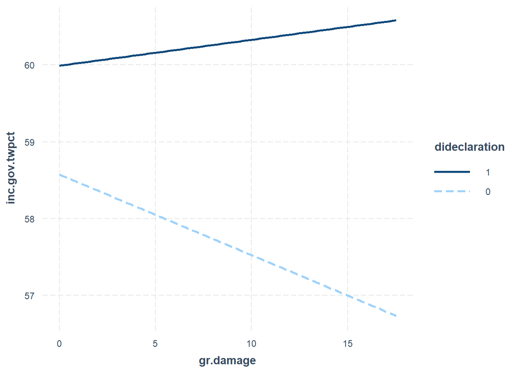

```r
#Construct an interaction plot using the interact_plot() function from the interactions package
interactions::interact_plot(vote_model_interaction, "gr.damage", "dideclaration")
```

**Source**

```r
#Note: to replicate the article, you should include as.factor(fips) and as.factor(year) in the regression model to control for fixed effects of country and year - that makes it a bit slow to run and doesn't change the results substantively, so no need to do it here.
```

## Interaction of two continuous variables - ethnic conflict and elections

Paul Collier popularised the idea that democracy is actually harmful for development when countries experience lots of ethnic or religious conflict (see his Wars, Guns and Votes book). Actually testing this is hard, partly because it requires looking at the same countries at multiple timepoints, which requires dealing with repeated measures. To keep it simple, let’s see if we can find the relationship he proposes in cross-sectional data. For that, we will use the Human Development Index - a combination of life expectancy, education and per capita income.

**Source**

```r
#Download the dataset
democracydata <- read_csv("http://empower-training.de/Gold/democracyData.csv")
```

**Message**

**Source**

```r
#In this dataset, the HDI (Human Development Index) comes from UNDP, while the data on elections and conflict come from the "The Global State of Democracy Indices"

#Run a linear regression model predicting HDI in 2010 from group_conflict and elected_gov in 1990 WITHOUT an interaction
#(both of these are scaled from 0 to 1 and effectively express ranks, group_conflict refers to both ethnic and religious conflict)
lm(HDI_2010 ~ group_conflict_1990+elected_gov_1990, democracydata) %>% summary()
```

**Output**

```
##
## Call:
## lm(formula = HDI_2010 ~ group_conflict_1990 + elected_gov_1990,
##     data = democracydata)
##
## Residuals:
##      Min       1Q   Median       3Q      Max
## -0.29992 -0.11685  0.00524  0.11794  0.31998
##
## Coefficients:
##                     Estimate Std. Error t value Pr(>|t|)
## (Intercept)          0.58762    0.03769  15.589  < 2e-16 ***
## group_conflict_1990 -0.12990    0.06401  -2.030   0.0447 *
## elected_gov_1990     0.20043    0.04081   4.911 3.05e-06 ***
## ---
## Signif. codes:  0 '***' 0.001 '**' 0.01 '*' 0.05 '.' 0.1 ' ' 1
##
## Residual standard error: 0.1446 on 114 degrees of freedom
##   (40 observations deleted due to missingness)
## Multiple R-squared:  0.2477, Adjusted R-squared:  0.2345
## F-statistic: 18.77 on 2 and 114 DF,  p-value: 8.978e-08
```

**Source**

```r
#Run the same model with an interaction
lm(HDI_2010 ~ group_conflict_1990*elected_gov_1990, democracydata) %>% summary()
```

**Output**

```
##
## Call:
## lm(formula = HDI_2010 ~ group_conflict_1990 * elected_gov_1990,
##     data = democracydata)
##
## Residuals:
##      Min       1Q   Median       3Q      Max
## -0.31051 -0.10230  0.01395  0.09706  0.31661
##
## Coefficients:
##                                      Estimate Std. Error t value Pr(>|t|)
## (Intercept)                           0.46187    0.04881   9.463 5.33e-16 ***
## group_conflict_1990                   0.28900    0.12641   2.286 0.024109 *
## elected_gov_1990                      0.37106    0.05945   6.241 7.80e-09 ***
## group_conflict_1990:elected_gov_1990 -0.64298    0.17030  -3.776 0.000256 ***
## ---
## Signif. codes:  0 '***' 0.001 '**' 0.01 '*' 0.05 '.' 0.1 ' ' 1
##
## Residual standard error: 0.1368 on 113 degrees of freedom
##   (40 observations deleted due to missingness)
## Multiple R-squared:  0.332,  Adjusted R-squared:  0.3143
## F-statistic: 18.72 on 3 and 113 DF,  p-value: 6.297e-10
```

**Source**

```r
#Is the interaction significant? What do the coefficients in the interaction mean?
```

In the way you have run the model, the coefficients outside the interaction term give you the slope of one variable when the value of the other variable is 0. Often, it might be more interesting to know its slope when the other variable is at its mean, especially when 0 is not a meaningful or even possible value. To get that value, you can center the variables before estimating the regression - that just means substracting the mean from each value. The easiest way to do that is to wrap each variable into the `scale()` function with the `scale =` parameter set to FALSE (otherwise you get z-Scores) - so for example, `scale(group_conflict_1990, scale = FALSE)` would give you the centered scores for `group_conflict` in 1990.

–> Estimate the same model again, this time centering the variables

**Source**

```r
#The scale() function needs an extra parameter each time, and then adds extra attributes that will get you into trouble later on, so that you would need to strip them - one of the situations where you would run into trouble and then need to consult Google for help - this code works:
democracydata <- democracydata %>% mutate(group_conflict_1990.c = c(scale(group_conflict_1990, scale=F)),elected_gov_1990.c = c(scale(elected_gov_1990, scale=F)))

#In these situations, it can be worth writing a simple function to save yourself from the complications in the future (and to save some typing)
center <- function(x) {c(scale(x, scale = FALSE))}

democracydata <- democracydata %>% mutate(group_conflict_1990.c = center(group_conflict_1990), elected_gov_1990.c = center(elected_gov_1990))

#Fit the new lm() model - what is the impact of elected governments at mean levels of group-based conflict and vice-versa?
lm(HDI_2010 ~ group_conflict_1990.c*elected_gov_1990.c, democracydata) %>% summary()
```

**Output**

```
##
## Call:
## lm(formula = HDI_2010 ~ group_conflict_1990.c * elected_gov_1990.c,
##     data = democracydata)
##
## Residuals:
##      Min       1Q   Median       3Q      Max
## -0.31051 -0.10230  0.01395  0.09706  0.31661
##
## Coefficients:
##                                          Estimate Std. Error t value Pr(>|t|)
## (Intercept)                               0.66631    0.01337  49.832  < 2e-16
## group_conflict_1990.c                    -0.11211    0.06076  -1.845 0.067661
## elected_gov_1990.c                        0.21600    0.03885   5.560 1.83e-07
## group_conflict_1990.c:elected_gov_1990.c -0.64298    0.17030  -3.776 0.000256
##
## (Intercept)                              ***
## group_conflict_1990.c                    .
## elected_gov_1990.c                       ***
## group_conflict_1990.c:elected_gov_1990.c ***
## ---
## Signif. codes:  0 '***' 0.001 '**' 0.01 '*' 0.05 '.' 0.1 ' ' 1
##
## Residual standard error: 0.1368 on 113 degrees of freedom
##   (40 observations deleted due to missingness)
## Multiple R-squared:  0.332,  Adjusted R-squared:  0.3143
## F-statistic: 18.72 on 3 and 113 DF,  p-value: 6.297e-10
```

**Source**

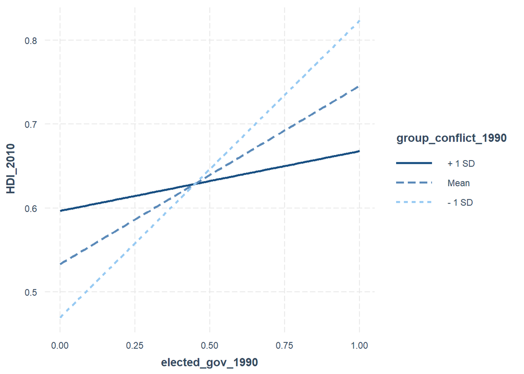

```r
#Simple slope plots, however, are a lot clearer when you do not scale the variables. So go back to the earlier model and then make a simple slopes plot to show how the relationship between the extent to which government jobs are filled by elections (elected_gov) and HDI changes depending on the level of group-based conflict.
fit <- lm(HDI_2010 ~ group_conflict_1990*elected_gov_1990, democracydata)
interact_plot(fit, pred = "elected_gov_1990", modx = "group_conflict_1990")
```

**Source**

```r
sim_slopes(fit, pred = "elected_gov_1990", modx = "group_conflict_1990")
```

**Output**

```
## JOHNSON-NEYMAN INTERVAL
##
## When group_conflict_1990 is OUTSIDE the interval [0.43, 0.96], the slope of
## elected_gov_1990 is p < .05.
##
## Note: The range of observed values of group_conflict_1990 is [0.00, 0.83]
##
## SIMPLE SLOPES ANALYSIS
##
## Slope of elected_gov_1990 when group_conflict_1990 = 0.03 (- 1 SD):
##
##   Est.   S.E.   t val.      p
## ------ ------ -------- ------
##   0.35   0.06     6.31   0.00
##
## Slope of elected_gov_1990 when group_conflict_1990 = 0.25 (Mean):
##
##   Est.   S.E.   t val.      p
## ------ ------ -------- ------
##   0.21   0.04     5.48   0.00
##
## Slope of elected_gov_1990 when group_conflict_1990 = 0.47 (+ 1 SD):
##
##   Est.   S.E.   t val.      p
## ------ ------ -------- ------
##   0.07   0.05     1.38   0.17
```

**Source**

```r
#Use the Johnson-Neyman function to find out at what values of group_conflict elected government positively predicts future HDI. Are there values when it negatively predicts it?
johnson_neyman(fit, pred = "elected_gov_1990", modx = "group_conflict_1990")
```

**Output**

```
## JOHNSON-NEYMAN INTERVAL
##
## When group_conflict_1990 is OUTSIDE the interval [0.43, 0.96], the slope of
## elected_gov_1990 is p < .05.
##
## Note: The range of observed values of group_conflict_1990 is [0.00, 0.83]
```

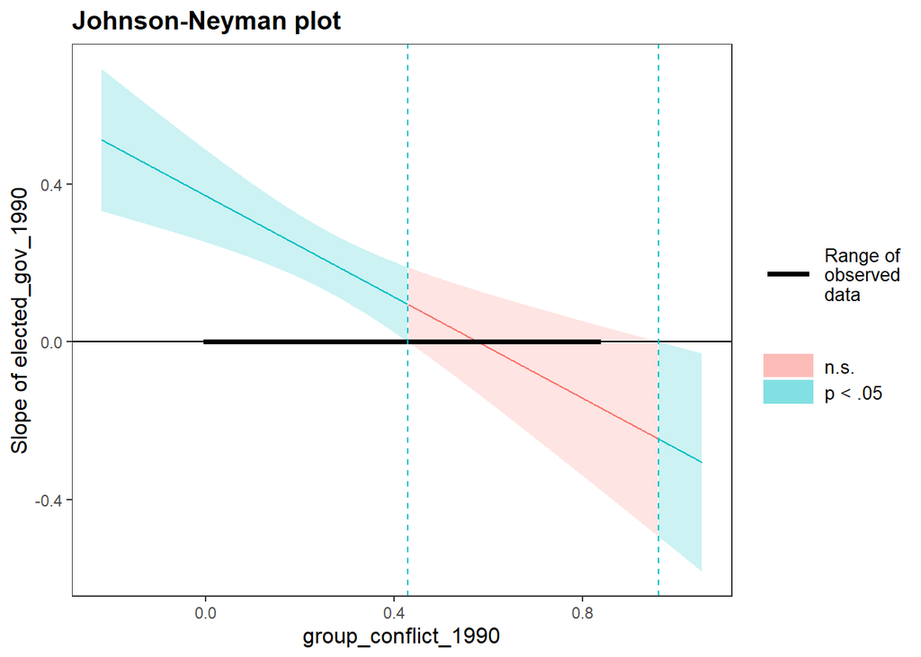

**Source**

```r
#Note that the values where there is potentially a negative effect are outside the observed range - so it would be very risky to conclude anything about them (extrapolation). This might (sometimes) serve as inspiration for future research, but you would only report the significant and non-significant regions within the observed range as findings.
```